# ClinicalData Inspection

Weilu

2023-05-10

```r
pacman::p_load(rio,here,skimr,tidyverse,dplyr,haven,codebookr,knitr,rlist,tools,janitor,fastDummies,labelled,magrittr,readxl,data.table,purrr,stringr,readxl,tidyr,fastDummies,questionr,sqldf,fs,kableExtra,lubridate,gtsummary)
```

```r
rm(list=ls())
```

```r
datanames<-list.files(here::here("q1"))
df<-list()
for (i in datanames){
  df[[i]]<-import(here::here("q1",i))
}
names(df) <- gsub(".csv", "", names(df))
for (i in 1:length(df)) {
  assign(names(df)[i], df[[i]])
}
list2env(df,.GlobalEnv)
```

```
## <environment: R_GlobalEnv>
```

```r
#Step1.Checking dataset
#"BrakeTime"
BrakeTime %<>%
  mutate(id = as.character(id))
s<-summary(BrakeTime)

kbl(s, caption ="Dataset Checking:BrakeTime")%>%
    kable_classic(full_width=F, html_font = "Cambria")
```

Dataset Checking:BrakeTime

|  | id | TIME |
| --- | --- | --- |
|  | Length:360 | Min. : 0.00 |
|  | Class :character | 1st Qu.: 0.71 |
|  | Mode :character | Median : 2.13 |
|  | NA | Mean :17224.56 |
|  | NA | 3rd Qu.: 8.40 |
|  | NA | Max. :99999.00 |

```r
#randomizedData
randomizedData %<>%
  mutate(id = as.character(id))
s2<-summary(randomizedData)

kbl(s2, caption ="Dataset Checking:randomizedData")%>%
    kable_classic(full_width=F, html_font = "Cambria")
```

Dataset Checking:randomizedData

|  | id | GENDER | DOSE |
| --- | --- | --- | --- |
|  | Length:180 | Length:180 | Length:180 |
|  | Class :character | Class :character | Class :character |
|  | Mode :character | Mode :character | Mode :character |

```r
#Step2. Merge the two dataset
#Check whether the "id" variable is duplicated in both datasets.
length(unique(BrakeTime$id))
```

```
## [1] 360
```

```r
length(unique(randomizedData$id))
```

```
## [1] 180
```

```r
#Verify if the dataset "BrakeTime" contains 180 or more unique IDs compared to the dataset "randomizedDataset." Additionally, check for any duplicated IDs that may exist in both datasets.

idb<-randomizedData$id
dfc2<-BrakeTime%>%
  filter(!(id %in% idb))
length(dfc2$id)
```

```
## [1] 180
```

```r
identical(idb,dfc2$id) # Check if the IDs are identical for the purpose of merging the datasets.
```

```
## [1] FALSE
```

```r
# Merge the two datasets by performing a left join with the "randomizedDataset" as the dominant dataset and the "BrakeTime" dataset. Create a new dataset called "dfc" and use the common primary key (PK) "id" to match and add the "time" variable from the "BrakeTime" dataset to the corresponding records in the "randomizedDataset".

dfc<-randomizedData %>%
  left_join(BrakeTime, by="id")%>%
  mutate(DOSE=factor(DOSE),
         GENDER=factor(GENDER),
         id=as.character(id))

#quick check dfc dataset
s2<-summary(dfc)
kbl(s2, caption ="Dataset Checking")%>%
    kable_classic(full_width=F, html_font = "Cambria")
```

Dataset Checking

|  | id | GENDER | DOSE | TIME |
| --- | --- | --- | --- | --- |
|  | Length:180 | FEMALE:90 | 0.00 CC/LB:60 | Min. : 0.000846 |
|  | Class :character | MALE :90 | 0.25 CC/LB:60 | 1st Qu.: 0.433978 |
|  | Mode :character | NA | 0.50 CC/LB:60 | Median : 1.185666 |
|  | NA | NA | NA | Mean : 2.332896 |
|  | NA | NA | NA | 3rd Qu.: 2.917141 |
|  | NA | NA | NA | Max. :18.430484 |

**QUESTION 1**

**A. Provide a descriptive table of response time by alcohol dose. Please document any data cleaning you conducted and any assumptions made with the data.**

```r
#Construct a descriptive table by different DOSE levels using the gtsummary package.

dfc%>%
  select(TIME, GENDER, DOSE)%>%
  tbl_summary(by=DOSE,
              missing="no")%>%
  add_p()%>%
  add_overall()%>%
  add_n()%>%
  modify_header(label = "**Variable**") %>% # update the column header
  bold_labels()%>%
  modify_spanning_header(c("stat_1", "stat_2", "stat_3") ~ "**Dose Level**") %>%
  modify_caption("**Table 1. Descriptive table for Dataset**")
```

**Table 1. Descriptive table for Dataset**

| **Variable** | **N** | **Overall**, N = 180<sup>1</sup> | **Dose Level** **0.00 CC/LB**, N = 60<sup>1</sup> | **Dose Level** **0.25 CC/LB**, N = 60<sup>1</sup> | **Dose Level** **0.50 CC/LB**, N = 60<sup>1</sup> | **p-value**<sup>2</sup> |  |
| --- | --- | --- | --- | --- | --- | --- | --- |
| TIME | 180 | 1.19 (0.43, 2.92) | 0.76 (0.18, 1.22) | 1.18 (0.44, 2.32) | 2.82 (1.18, 5.62) |  | <0.001 |
| GENDER | 180 |  |  |  |  | >0.9 |  |
| FEMALE |  | 90 (50%) | 30 (50%) | 30 (50%) | 30 (50%) |  |  |
| MALE |  | 90 (50%) | 30 (50%) | 30 (50%) | 30 (50%) |  |  |

<sup>1</sup> Median (IQR); n (%)  
<sup>2</sup> Kruskal-Wallis rank sum test; Pearson’s Chi-squared test

**B. Provide analyses that investigates the relationship between alcohol dose level and response time. Provide any graphs/outputs and interpretation of the graphs/outputs needed to assess the assumptions required for your analysis. If you decide to transform the data, provide justification for the decision.**

```r
#Since the outcome variable is continuous and there are no confounding factors requiring adjustment at this stage, an ANOVA analysis can be conducted.

# perform ANOVA
fit <- aov(TIME ~ DOSE, data = dfc)

# summarize results
summary(fit)
```

```
##              Df Sum Sq Mean Sq F value   Pr(>F)
## DOSE          2  302.8  151.38   20.43 1.04e-08 ***
## Residuals   177 1311.4    7.41
## ---
## Signif. codes:  0 '***' 0.001 '**' 0.01 '*' 0.05 '.' 0.1 ' ' 1
```

**Answer:**The table presents the results of the analysis for the variables “TIME” and “GENDER” in relation to different dose levels.Among total 180 participants,significant differences were observed for “TIME” across the dose levels (p < 0.001), with increasing means observed as the dose level increased. No significant differences were found for “GENDER” across the dose levels. The ANOVA analysis was performed to examine the impact of the variable “DOSE” on the response variable. The data consisted of 2 degrees of freedom for the “DOSE” factor and 177 degrees of freedom for the residuals. The analysis revealed a significant effect of “DOSE” on the response variable, as indicated by a high F value of 20.43 (p < 0.001). The sum of squares for the “DOSE” factor was 302.8, with a mean square of 151.38. The remaining variability in the data was captured by the residuals, with a sum of squares of 1311.4 and a mean square of 7.41. These results strongly support the conclusion that the variable “DOSE” has a significant impact on the response variable.

**C. After the investigator reviews your analyses for part B, she would like to look at whether gender in uences this relationship. Provide additional analyses that looks at the relationship between alcohol dose, gender,and response time. Provide any graphs/outputs and interpretation of the graphs/outputs needed to assess the assumptions required for your analysis.** \

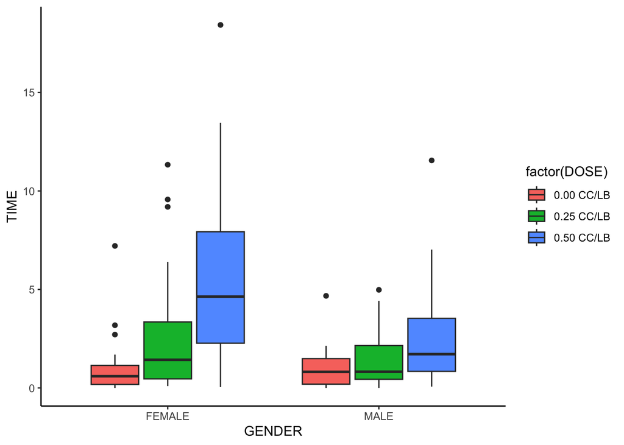

```r
#Viz grouped by GENDER

ggplot(data =dfc, aes(GENDER, TIME)) +
    geom_boxplot(aes(fill = factor(DOSE)))+
    theme_classic()
```

```r
#Linear model

lm1<-lm(TIME ~GENDER+DOSE, data =dfc)
summary(lm1)
```

```
##
## Call:
## lm(formula = TIME ~ GENDER + DOSE, data = dfc)
##
## Residuals:
##     Min      1Q  Median      3Q     Max
## -4.7263 -1.5099 -0.4755  0.8569 13.6592
##
## Coefficients:
##                Estimate Std. Error t value Pr(>|t|)
## (Intercept)      1.6590     0.3931   4.221 3.90e-05 ***
## GENDERMALE      -1.3969     0.3931  -3.554 0.000487 ***
## DOSE0.25 CC/LB   1.0048     0.4814   2.087 0.038302 *
## DOSE0.50 CC/LB   3.1124     0.4814   6.465 9.62e-10 ***
## ---
## Signif. codes:  0 '***' 0.001 '**' 0.01 '*' 0.05 '.' 0.1 ' ' 1
##
## Residual standard error: 2.637 on 176 degrees of freedom
## Multiple R-squared:  0.242,  Adjusted R-squared:  0.2291
## F-statistic: 18.73 on 3 and 176 DF,  p-value: 1.375e-10
```

Based on the plot, there are clear distinctions in time responses between males and females, particularly in the high dose group. To delve deeper into this relationship, a linear regression model was built, revealing that the varying doses significantly impacted time after accounting for gender. Moreover, the model highlighted the noteworthy influence of gender on the outcome, with males demonstrating shorter time responses compared to females.

**QUESTION 2**

```r
#Import the dataset
dfq2<-rio::import(here::here("q2","preprocessedfluids.csv"))%>%
  mutate(type=factor(type),
         time=factor(time),
         ptid=as.character(ptid),
         num=as.factor(num))

str(dfq2) #Check the structure of new dataset dfq2.
```

```
## 'data.frame':    583 obs. of  5 variables:
##  $ ptid  : chr  "30000" "30000" "30000" "30000" ...
##  $ num   : Factor w/ 7 levels "1","2","3","4",..: 1 2 3 4 5 1 1 2 3 1 ...
##  $ type  : Factor w/ 3 levels "0","1","2": 3 3 3 1 1 3 1 1 1 1 ...
##  $ time  : Factor w/ 2 levels "0","1": 2 2 2 2 2 2 1 2 2 2 ...
##  $ volume: int  694 745 415 201 446 589 99 887 266 261 ...
```

**1. Please create the wide-format dataset (postprocesseduids.csv) as described above, using a program of your choice (i.e., R, SAS, STATA, or PYTHON)?**

```r
wide_data <- dfq2 %>%
  mutate(num = as.numeric(num)) %>%
  group_by(ptid, type) %>%
  mutate(svol = sum(volume)) %>%
  mutate(snum = n(),
         totyn=type)%>%
  ungroup() %>%
  group_by(ptid) %>%
  mutate(totvolusvol = sum(volume),
         totvolusyn = factor(ifelse(is.na(type), 0, 1))) %>%
  ungroup() %>%
  select(-c("num","time","volume"))%>%
  group_by(ptid, type) %>%
  distinct(svol,.keep_all = T) %>% #To solve "not unique identified value" for svol, snum in the pivot_wider process
  pivot_wider(
    names_from = "type",
    names_prefix = "type_",
    names_sep = "_",
    values_from = c("svol","snum","totyn")
  )%>%
  rowwise() %>%
  mutate(totnum=sum(snum_type_0,snum_type_1,snum_type_2,snum_type_NA, na.rm = TRUE), #get total number of flu shot received.
        totyn_type_NA =ifelse(is.na(totyn_type_NA),0, 1),
        totyn_type_0 = ifelse(is.na(totyn_type_0),0, 1),
        totyn_type_1 = ifelse(is.na(totyn_type_1),0, 1),
        totyn_type_2 = ifelse(is.na(totyn_type_2),0, 1)) %>%
  select(ptid,
         totbol0yn=totyn_type_0, totbol2yn=totyn_type_2, totbol1yn=totyn_type_1,
         totbol0num=snum_type_0, totbol2num=snum_type_2, totbol1num=snum_type_1,
         totbo0vol=svol_type_0, totbo2vol=svol_type_2, totbo1vol=svol_type_1,
         totbolusnum=totnum,
         totbolusyn=totvolusyn,
         totbolusvol=totvolusvol
         )%>% #rename and reorder the dataset to align with the example dataset.remove the xxx_NA if the whole column does not have any value.
  filter(ptid!=30089)#remove the outlier: ptid=30089 does not receive any type of flu shot but got the total volume input based on the wide dataset example.


#Export dataset
rio::export(wide_data,"wide_data.csv")
```

**2. How many unique patient records do you have in the new dataset?**

```r
length(unique(dfq2$ptid))
```

```
## [1] 201
```

**3. Describe any data anomalies in either dataset that you found.**

```r
# 1. Use original long-format dataset
summary(dfq2)
```

```
##      ptid                num        type       time         volume
##  Length:583         1      :200   0   :378   0   :127   Min.   :  4.0
##  Class :character   2      :179   1   :  2   1   :455   1st Qu.:247.5
##  Mode  :character   3      :132   2   :202   NA's:  1   Median :464.0
##                     4      : 51   NA's:  1              Mean   :483.8
##                     5      : 15                         3rd Qu.:728.5
##                     (Other):  5                         Max.   :999.0
##                     NA's   :  1
```

From this summary, we can see that there is one missing value in the “type” variable.The “num” variable seems to represent time to get vaccination, which should be 1-5, but here there are 5 other values as outliers.The “type” variable appears to be a categorical variable with three categories: 0, 1, and 2. There are 378 observations with type 0, 2 observations with type 1, and 202 observations with type 2.The “time” variable seems to have two categories, 0 and 1, with 127 observations for time 0 and 455 observations for time 1.The “volume” variable appears to be a numerical variable with a minimum of 4, maximum of 999, and a mean of 483.8.It’s difficult to determine if there are any abnormalities in the data without additional information, but it seems like there are no major outliers or unusual values in the dataset.From the summary we can also tell that there are 1 missing value from variable num, type and time respectively.

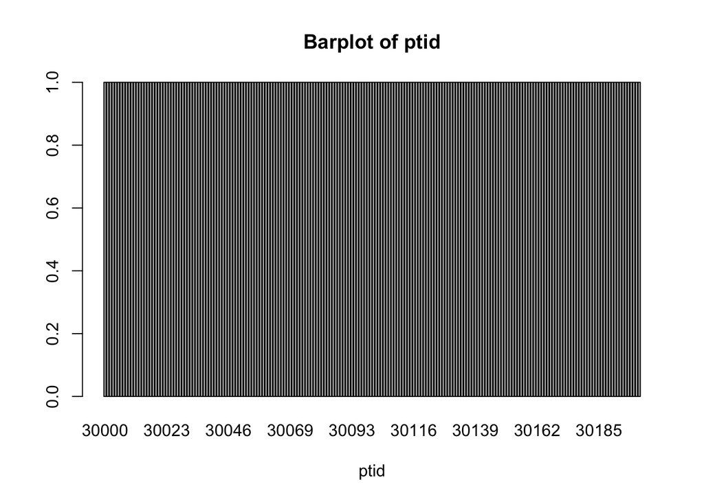

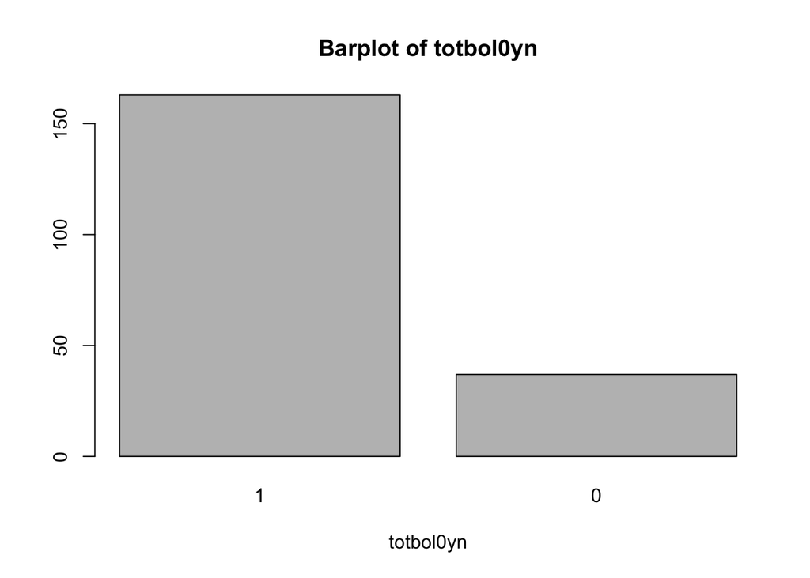

Table of totbol0yn

| Var1 | Freq |
| --- | --- |
| 1 | 163 |
| 0 | 37 |

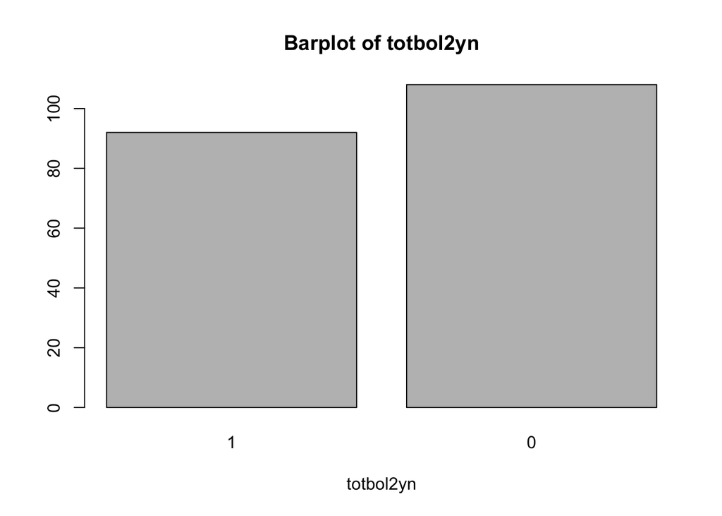

Table of totbol2yn

| Var1 | Freq |
| --- | --- |
| 1 | 92 |
| 0 | 108 |

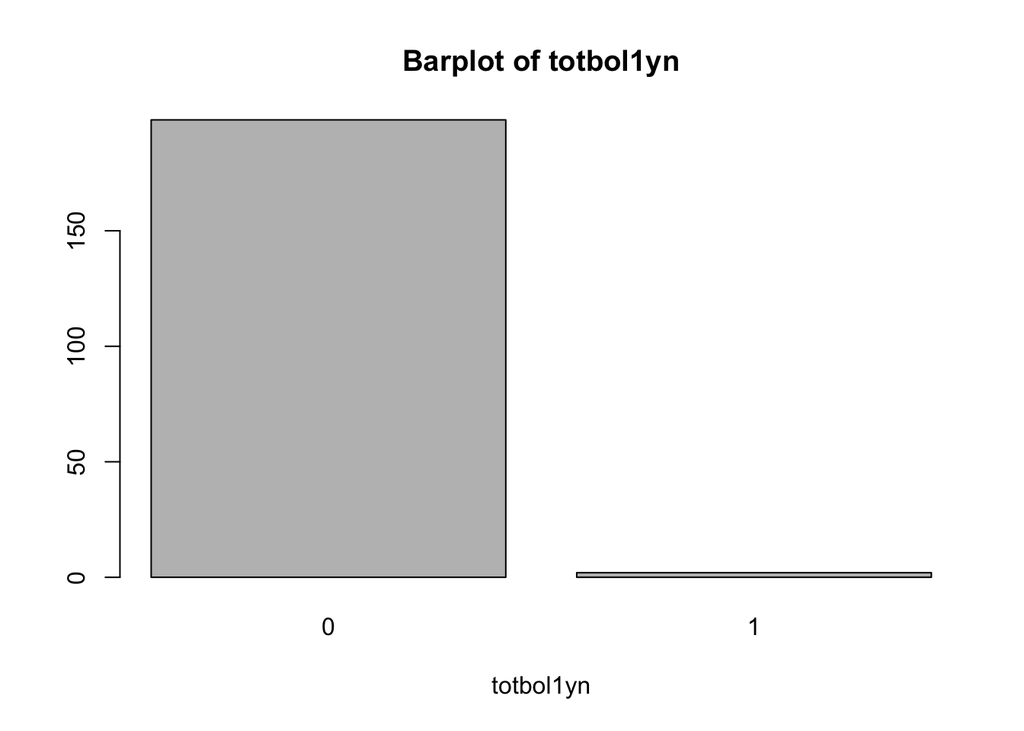

Table of totbol1yn

| Var1 | Freq |
| --- | --- |
| 0 | 198 |
| 1 | 2 |

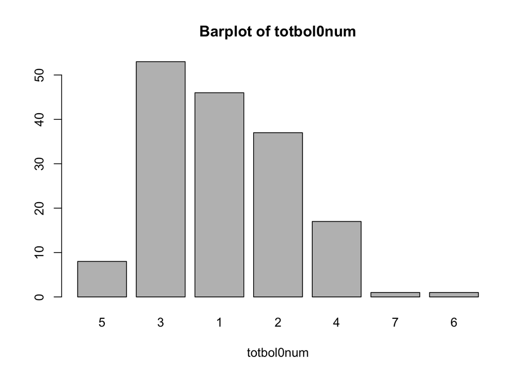

Table of totbol0num

| Var1 | Freq |
| --- | --- |
| 5 | 8 |
| 3 | 53 |
| 1 | 46 |
| 2 | 37 |
| 4 | 17 |
| 7 | 1 |
| 6 | 1 |
| NA | 37 |

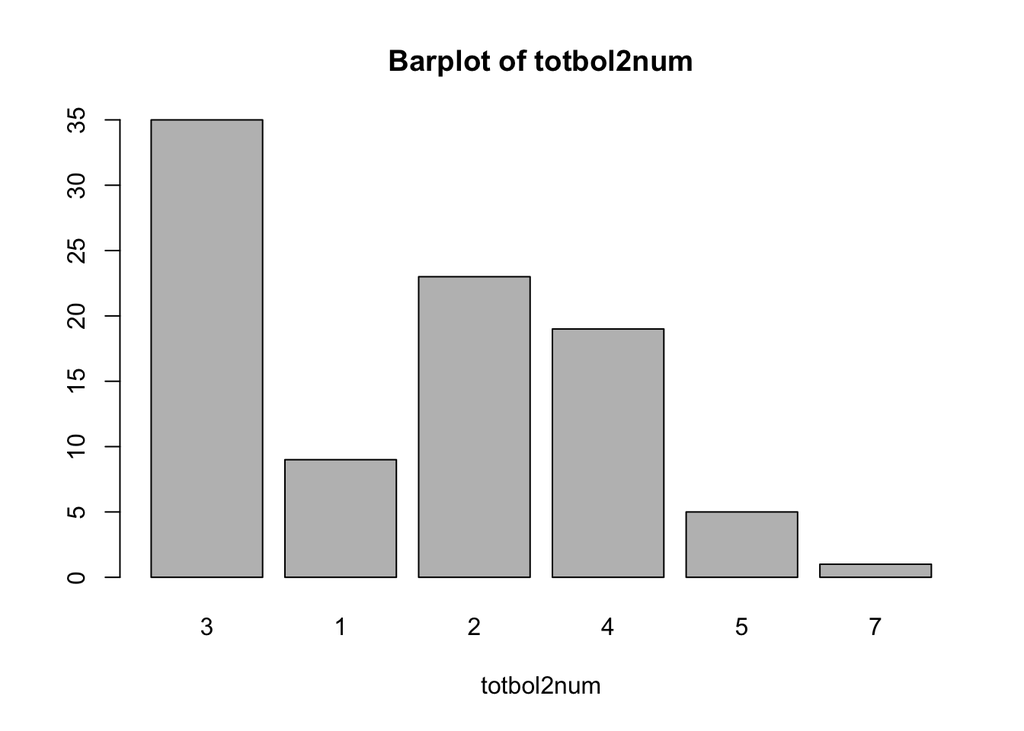

Table of totbol2num

| Var1 | Freq |
| --- | --- |
| 3 | 35 |
| 1 | 9 |
| 2 | 23 |
| 4 | 19 |
| 5 | 5 |
| 7 | 1 |
| NA | 108 |

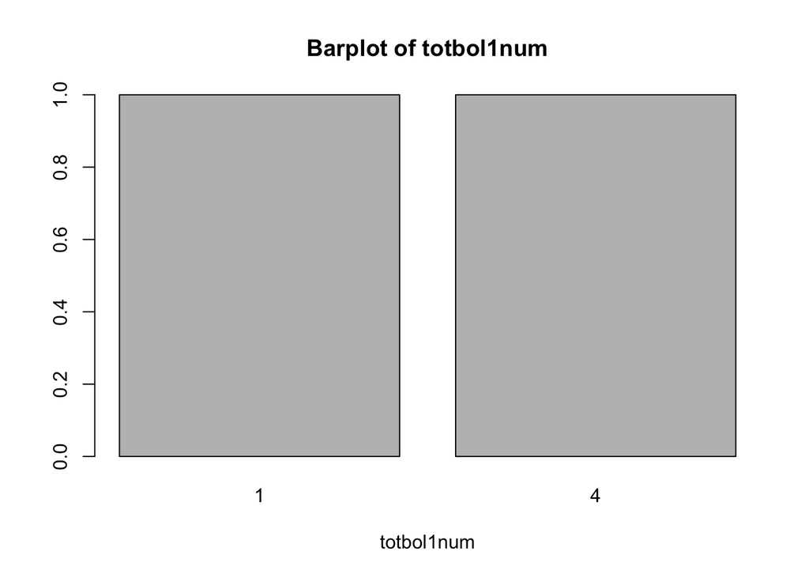

Table of totbol1num

| Var1 | Freq |
| --- | --- |
| 1 | 1 |
| 4 | 1 |
| NA | 198 |

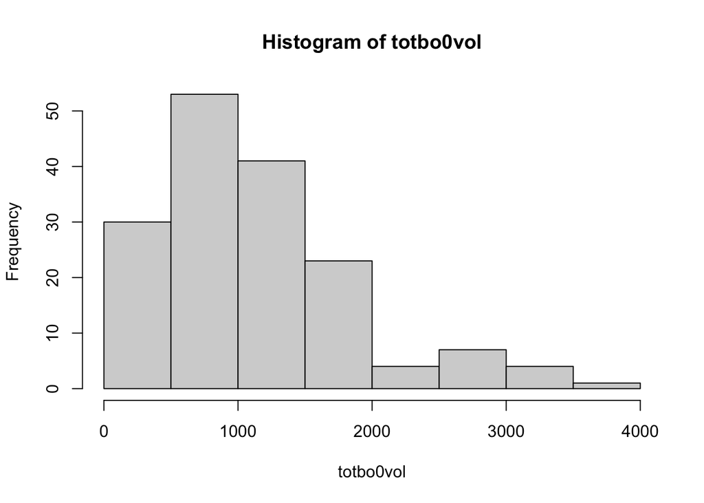

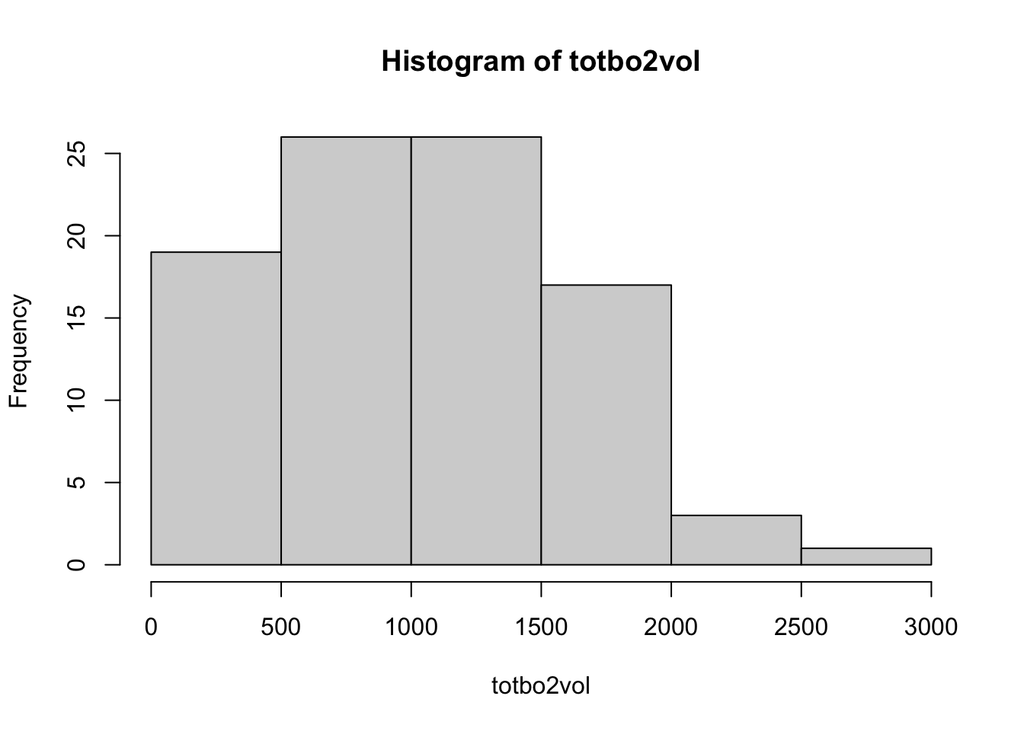

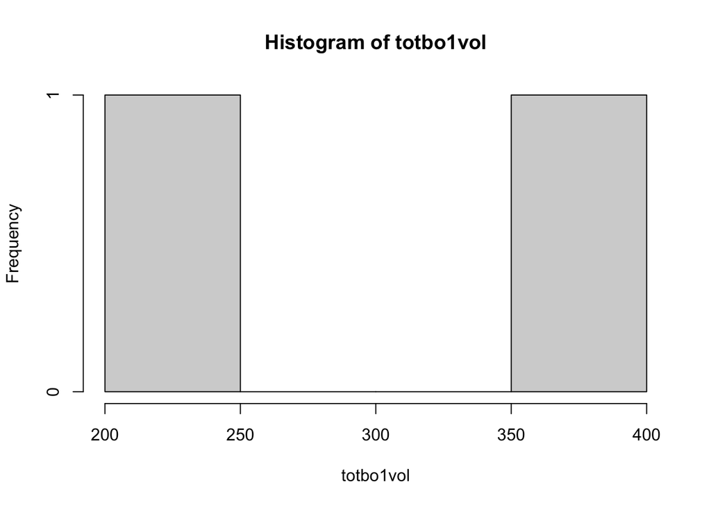

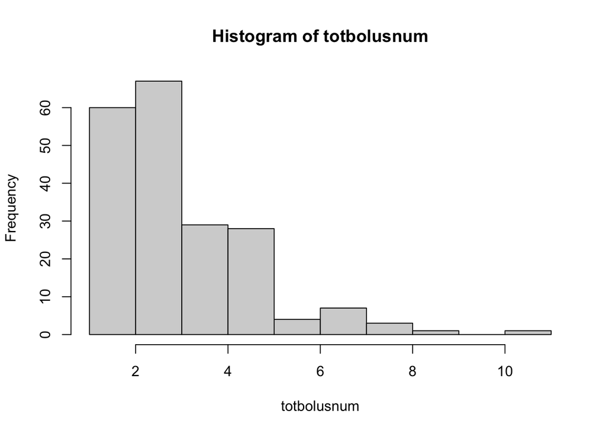

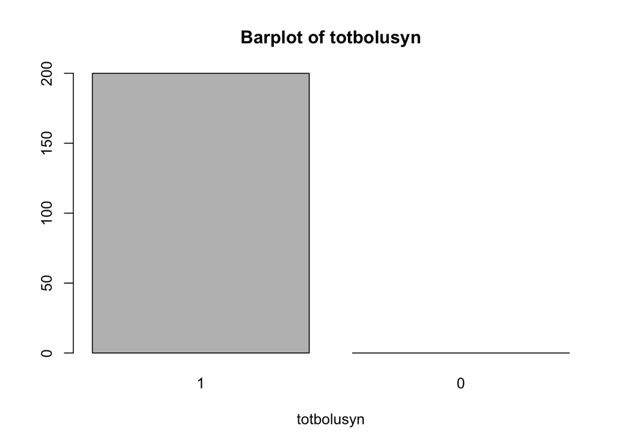

Table of totbolusyn

| Var1 | Freq |
| --- | --- |
| 1 | 200 |
| 0 | 0 |

[1 more figures not shown]

```r
# Use the reshaped wide format dataset to check outlier.

# --------------------------Copy from previous chunk for Rmarkdown to successfully Knit.------------------
wide_data <- dfq2 %>%
  mutate(num = as.numeric(num)) %>%
  group_by(ptid, type) %>%
  mutate(svol = sum(volume)) %>%
  mutate(snum = max(num),
         totyn=type)%>%
  ungroup() %>%
  group_by(ptid) %>%
  mutate(totvolusvol = sum(volume),
         totvolusyn = factor(ifelse(is.na(type), 0, 1))) %>%
  ungroup() %>%
  select(-c("num","time","volume"))%>%
  group_by(ptid, type) %>%
  distinct(svol,.keep_all = T) %>% #To solve "not unique identified value" for svol, snum in the pivot_wider process
  pivot_wider(
    names_from = "type",
    names_prefix = "type_",
    names_sep = "_",
    values_from = c("svol","snum","totyn")
  )%>%
  rowwise() %>%
  mutate(totnum=sum(snum_type_0,snum_type_1,snum_type_2,snum_type_NA, na.rm = TRUE), #get total number of flu shot received.
        totyn_type_NA =ifelse(is.na(totyn_type_NA),0, 1),
        totyn_type_0 = ifelse(is.na(totyn_type_0),0, 1),
        totyn_type_1 = ifelse(is.na(totyn_type_1),0, 1),
        totyn_type_2 = ifelse(is.na(totyn_type_2),0, 1)) %>%
  select(ptid,
         totbol0yn=totyn_type_0, totbol2yn=totyn_type_2, totbol1yn=totyn_type_1,
         totbol0num=snum_type_0, totbol2num=snum_type_2, totbol1num=snum_type_1,
         totbo0vol=svol_type_0, totbo2vol=svol_type_2, totbo1vol=svol_type_1,
         totbolusnum=totnum,
         totbolusyn=totvolusyn,
         totbolusvol=totvolusvol
         )%>% #rename and reorder the dataset to align with the example dataset.
  filter(ptid!=30089)#remove the outlier: ptid=30089 does not receive any type of flu shot but got the total volume input.
#-------------------End of copied code---------------------------------------------

#Reshape the format of variables to better see outliers

wd<-wide_data%>%
  mutate(totbol0yn=factor(totbol0yn),
         totbol1yn=factor(totbol1yn),
         totbol2yn=factor(totbol2yn),
         totbol0num=factor(totbol0num),
         totbol1num=factor(totbol1num),
         totbol2num=factor(totbol2num))


#Check outliers by using visualized plots based on the format of var

for (i in colnames(wd)) {
  if (is.numeric(wd[[i]])) {
    hist(wd[[i]], main = paste("Histogram of", i), xlab = i)
  } else if (is.character(wd[[i]])) {
    barplot(table(wd[[i]]), main = paste("Barplot of", i), xlab = i)
  } else if (is.factor(wd[[i]])) {
    barplot(table(wd[[i]]), main = paste("Barplot of", i), xlab = i)
    tbl <- table(wd[[i]], useNA = "ifany")
    print(kbl(tbl, caption = str_c("Table of"," ", i )))
  }
}
```

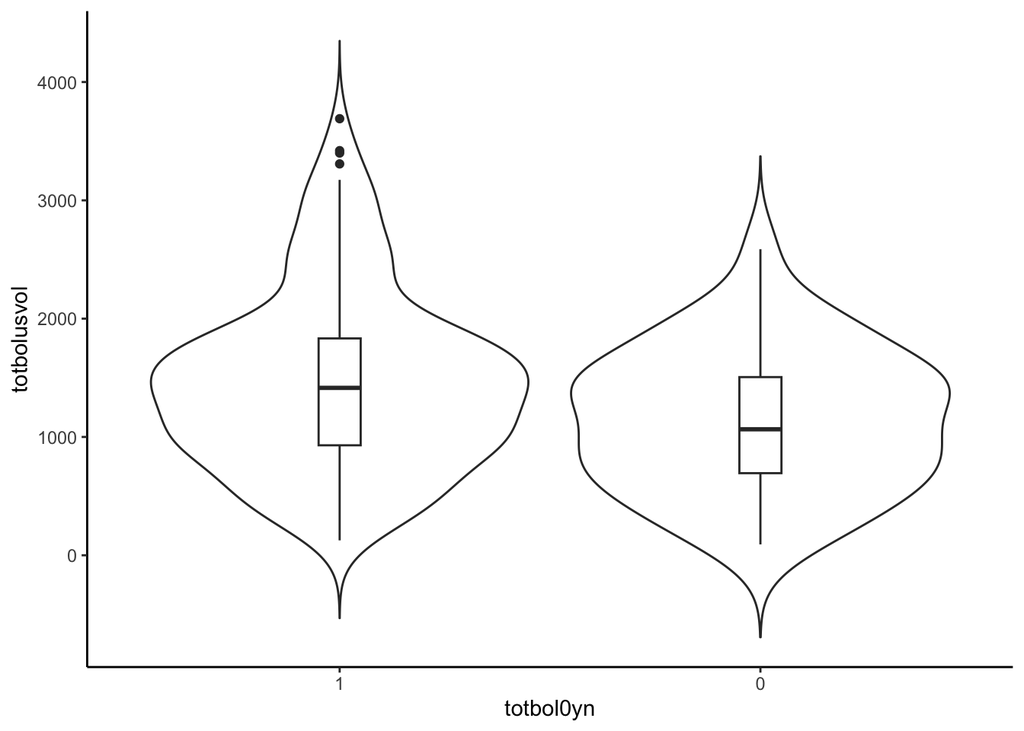

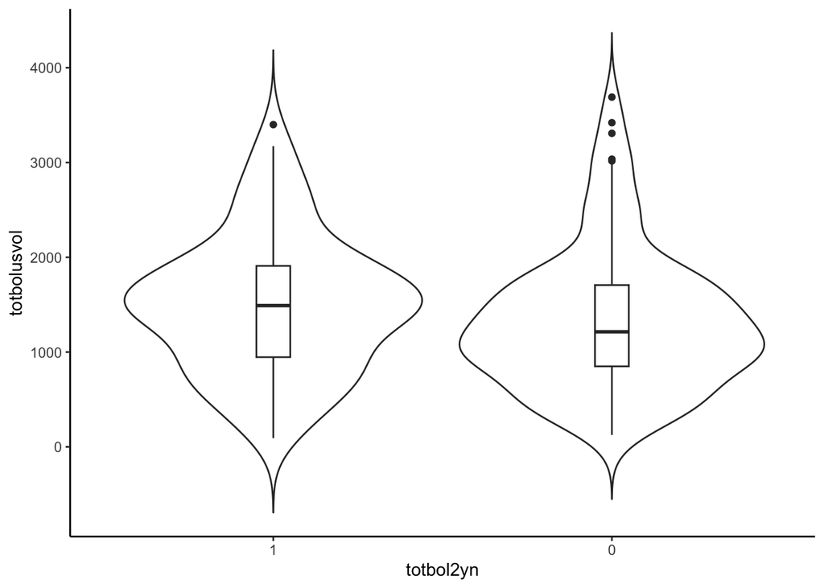

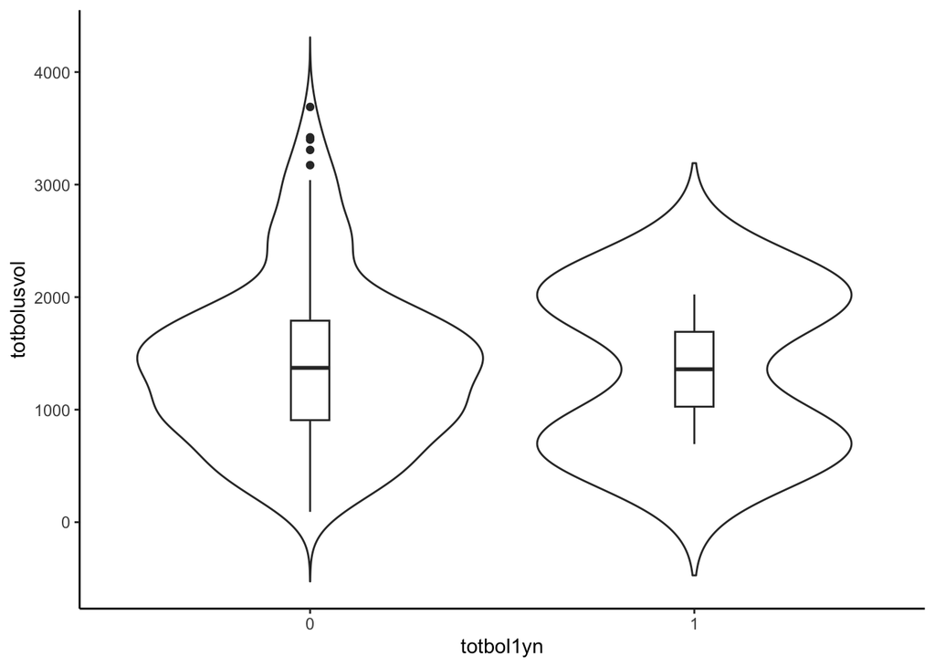

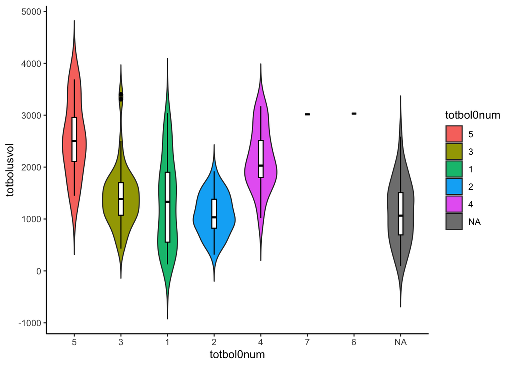

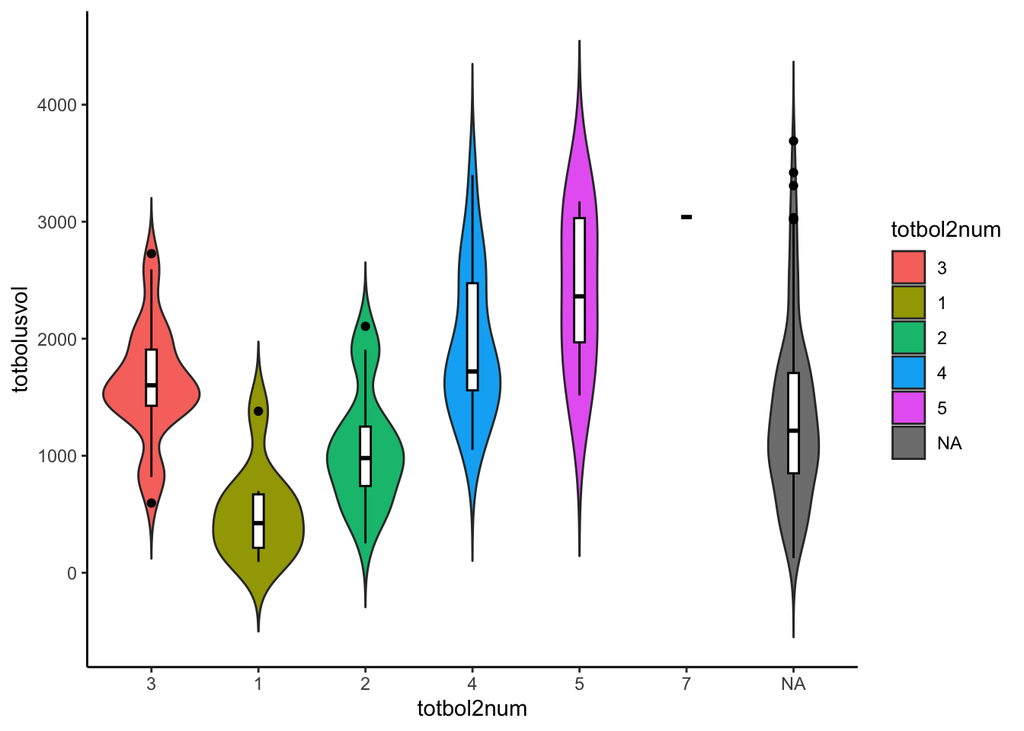

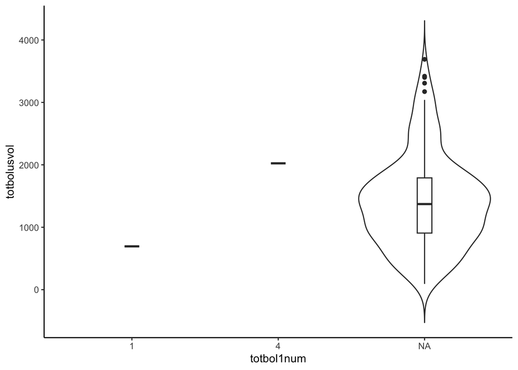

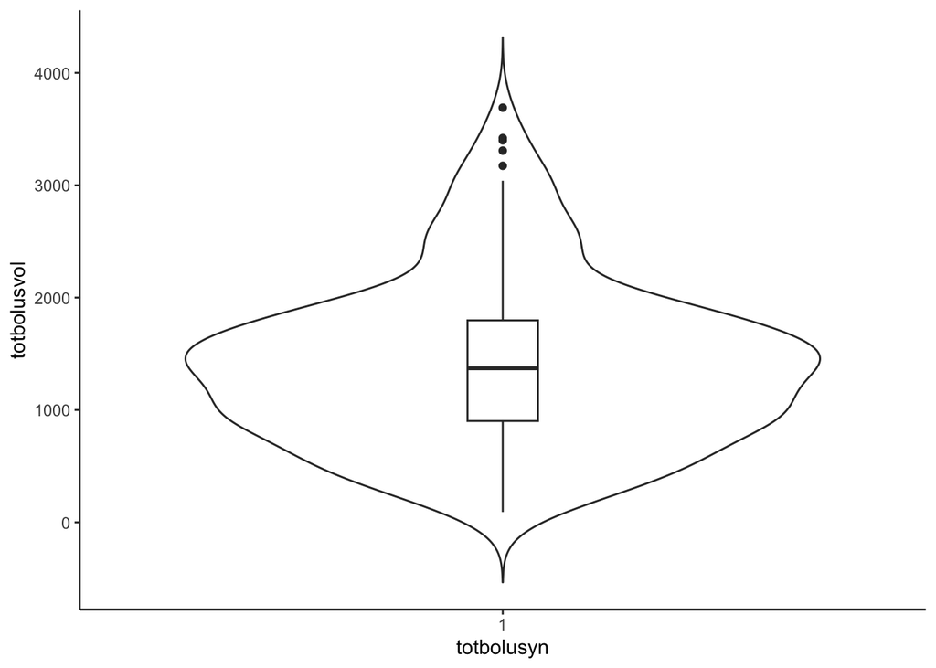

```r
#Further check factor variables for distribution and outliers
for (i in colnames(wd)) {
  if (is.factor(wd[[i]]) && length(levels(wd[[i]])) >1 && length(levels(wd[[i]])) <= 2) {
    p <- ggplot(data = wd, aes_string(x = i, y = "totbolusvol")) +
      geom_violin(trim = FALSE, na.rm = TRUE) +
      geom_boxplot(width = 0.1,  na.rm = TRUE) +
      theme_classic()
    print(p)
  }
  else if (is.factor(wd[[i]]) && length(levels(wd[[i]])) > 2) {
    p2 <- ggplot(data = wd, aes_string(x = i, y = "totbolusvol")) +
      geom_violin(aes(fill = .data[[i]]), trim = FALSE, na.rm = TRUE) +
      geom_boxplot(width = 0.1, fill = "white", color = "black",  na.rm = TRUE) +
      theme_classic()
    print(p2)
  }
}
```

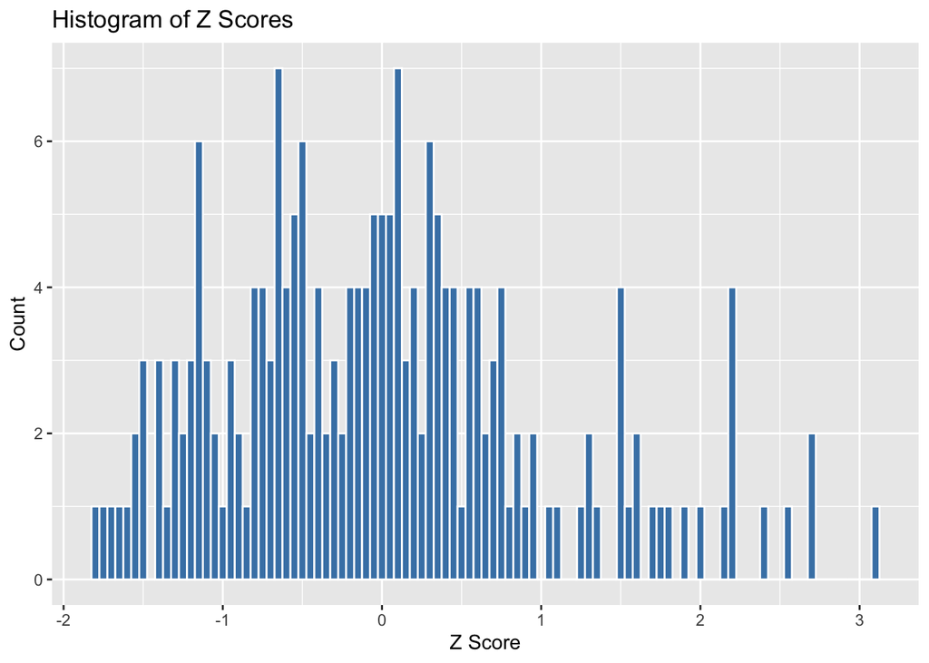

```r
#checking by z-score: volume
z_scores_df <- as_tibble(scale(wide_data$totbolusvol))
ggplot(z_scores_df, aes(x = V1)) +
  geom_histogram(binwidth = 0.05, fill = "steelblue", color = "white") +
  labs(title = "Histogram of Z Scores", x = "Z Score", y = "Count")
```